# MC1: The HarborCrest Breach — Visual Analytics of TenantThread’s Embargo Failure

- Show All Code
- Hide All Code
- View Source

IS428 Visual Analytics for Business Intelligence — Mini-Challenge 1

Author

Student Submission

Published

May 29, 2026

# 1. Overview

## 1.1 Background

TenantThread is a property technology company whose flagship “Retention Optimizer” product scored tenants on payment behaviour, maintenance requests, and message sentiment — then flagged residents as “high-friction.” A local newspaper, the *SaltWind Journal*, had been running an exposé under the hashtag **#AlgorithmicEviction**.

Simultaneously, TenantThread was negotiating a merger with **CivicLoom Realty Partners**, codenamed **Project HarborCrest**. The merger announcement was under a strict information embargo until **6:00 PM on June 5th, 2046**. An automated compliance agent — referred to as **“The Judge”** — was installed to prevent leaks.

Despite these safeguards, embargoed merger information appeared on the social media platform *FleX* by accounts associated with TenantThread around 5:00 PM — one hour before the official embargo lifted. **CivicLoom’s legal team must now determine: was this a deliberate leak or a system breakdown under crisis pressure?**

## 1.2 Dataset

The dataset `MC1_final_00.json` contains 23 simulated rounds spanning **May 17–June 5, 2046**, covering 912 messages across 7 AI agents, 6 communication channels, and 5 types of message actions.

| Dimension | Detail |
| --- | --- |
| **Time period** | May 17, 2046 – June 5, 2046 (23 rounds) |
| **Total messages** | 912 |
| **Agents** | 7 (Legal, Platform-Trust, PR, Social-Manager, PR-Intern, Intern, Judge) |
| **Channels** | comms_huddle, one_on_one_chat, side_huddle, official_post, personal_post, anonymous_post |
| **Key event** | Embargo breach ~5:00 PM on June 5, 2046 |

## 1.3 R Packages Used

```r
pacman::p_load(
  # Core data wrangling
  tidyverse, jsonlite, lubridate,
  # jsonlite provides read_json() which returns native R lists — safer than
  # fromJSON(flatten=TRUE) which coerces rounds into a data frame.

  # Visualisation
  ggplot2, ggrepel, patchwork, ggthemes, hrbrthemes,

  # Interactive plots
  plotly, ggiraph, DT,

  # Network / relational
  igraph, ggraph, tidygraph,

  # Distribution plots
  ggridges, ggdist,

  # Color utilities
  colorspace, RColorBrewer, viridis
)
```

# 2. Data Import and Wrangling

## 2.1 Loading the JSON Data

The dataset is a deeply nested JSON structure with `rounds` as the top-level array. Each round contains `environment_context`, `communications`, and `participants` sub-objects.

**Note**

**Parsing note:** `jsonlite::fromJSON()` with its default `flatten = TRUE` coerces `rounds` into a data frame, making `rounds[[1]]` return the first *column* rather than the first *round*. We instead use `jsonlite::read_json()` which always returns native R lists, preserving the nested structure and allowing safe `[[i]]$field` access.

```r
# read_json() always returns a native R list (no coercion to data.frame)
raw_data    <- read_json("data/MC1_final_00.json")
rounds_list <- raw_data$rounds          # a list of 23 named lists

cat("Number of rounds:", length(rounds_list), "\n")
```

```
Number of rounds: 23
```

```r
cat("Round date range:", rounds_list[[1]]$hour, "to",
    rounds_list[[length(rounds_list)]]$hour, "\n")
```

```
Round date range: 2046-05-17T09:00:00 to 2046-06-05T18:00:00
```

## 2.2 Parsing Communications into a Flat Table

With `read_json()`, each round’s `communications` is a **list of named lists** (one per message). We use `map_dfr()` to iterate over rounds, then over individual messages inside each round, safely pulling scalar fields with `%||% NA_character_` to handle NULLs.

```r
# Helper: extract a scalar character from a possibly-NULL list element
pluck_chr <- function(x, key) {
  val <- x[[key]]
  if (is.null(val) || length(val) == 0) NA_character_ else as.character(val[[1]])
}

# Extract all communications into a flat tibble
messages_df <- map_dfr(rounds_list, function(r) {
  comms <- r$communications          # list of message objects
  if (is.null(comms) || length(comms) == 0) return(NULL)

  map_dfr(comms, function(msg) {
    # internal_state is a named list with reacting/rationalizing/deliberating
    is_obj <- msg$internal_state
    tibble(
      round_hour          = r$hour,
      message_id          = pluck_chr(msg, "message_id"),
      agent_id            = pluck_chr(msg, "agent_id"),
      agent_role          = pluck_chr(msg, "agent_role"),
      agent_label         = pluck_chr(msg, "agent_label"),
      channel             = pluck_chr(msg, "channel"),
      message_type        = pluck_chr(msg, "message_type"),
      responding_to       = pluck_chr(msg, "responding_to"),
      timestamp           = pluck_chr(msg, "timestamp"),
      content             = pluck_chr(msg, "content"),
      state_reacting      = if (is.null(is_obj)) NA_character_ else pluck_chr(is_obj, "reacting"),
      state_rationalizing = if (is.null(is_obj)) NA_character_ else pluck_chr(is_obj, "rationalizing"),
      state_deliberating  = if (is.null(is_obj)) NA_character_ else pluck_chr(is_obj, "deliberating")
    )
  })
}) %>%
  mutate(
    timestamp      = ymd_hms(timestamp),
    round_hour     = ymd_hms(round_hour),
    is_crisis_day  = date(timestamp) == as.Date("2046-06-05"),
    has_deliberation = !is.na(state_deliberating),
    content_length = nchar(content)
  )

cat("Total messages:", nrow(messages_df), "\n")
```

```
Total messages: 912
```

```r
glimpse(messages_df)
```

```
Rows: 912
Columns: 16
$ round_hour          <dttm> 2046-05-17 09:00:00, 2046-05-17 09:00:00, 2046-05…
$ message_id          <chr> "20460517_00_001", "20460517_00_002", "20460517_00…
$ agent_id            <chr> "legal_agent", "quality_agent", "quality_agent", "…
$ agent_role          <chr> "legal", "platform_trust", "platform_trust", "plat…
$ agent_label         <chr> "Legal-Agent", "Platform-Trust-Agent", "Platform-T…
$ channel             <chr> "comms_huddle", "comms_huddle", "comms_huddle", "c…
$ message_type        <chr> "broadcast", "broadcast", "broadcast", "broadcast"…
$ responding_to       <chr> NA, "20460517_00_001", "20460517_00_002", "2046051…
$ timestamp           <dttm> 2046-05-17 09:00:00, 2046-05-17 09:01:00, 2046-05…
$ content             <chr> "Morning. Let's keep today focused — Q2 planning k…
$ state_reacting      <chr> NA, NA, NA, NA, NA, NA, NA, NA, NA, NA, NA, NA, NA…
$ state_rationalizing <chr> NA, NA, NA, NA, NA, NA, NA, NA, NA, NA, NA, NA, NA…
$ state_deliberating  <chr> "Ajay's DM about \"strategic developments\" is unu…
$ is_crisis_day       <lgl> FALSE, FALSE, FALSE, FALSE, FALSE, FALSE, FALSE, F…
$ has_deliberation    <lgl> TRUE, TRUE, FALSE, FALSE, FALSE, TRUE, FALSE, TRUE…
$ content_length      <int> 175, 186, 191, 280, 258, 162, 185, 254, 247, 208, …
```

## 2.3 Parsing Participants and Declared Actions

```r
# Extract participant-level declared actions per round
participants_df <- map_dfr(rounds_list, function(r) {
  parts <- r$participants          # list of participant objects
  if (is.null(parts) || length(parts) == 0) return(NULL)

  map_dfr(parts, function(p) {
    meta <- p$agent_round_metadata
    tibble(
      round_hour            = r$hour,
      agent_id              = pluck_chr(p, "agent_id"),
      agent_role            = pluck_chr(p, "agent_role"),
      agent_label           = pluck_chr(p, "agent_label"),
      declared_action       = pluck_chr(p, "declared_action"),
      sentiment_at_turn     = if (is.null(meta)) NA_character_ else pluck_chr(meta, "sentiment_at_turn"),
      action_classification = if (is.null(meta)) NA_character_ else pluck_chr(meta, "action_classification")
    )
  })
}) %>%
  mutate(
    round_hour  = ymd_hms(round_hour),
    action_type = case_when(
      str_detect(coalesce(declared_action, ""), "POSTED_ON_FLEX")     ~ "Official Post",
      str_detect(coalesce(declared_action, ""), "POSTED_PERSONAL")    ~ "Personal Post",
      str_detect(coalesce(declared_action, ""), "POSTED_ANONYMOUS")   ~ "Anonymous Post",
      str_detect(coalesce(declared_action, ""), "COMPLIANCE_WARNING") ~ "Compliance Warning",
      str_detect(coalesce(declared_action, ""), "MONITORING")         ~ "Monitoring",
      TRUE                                                             ~ "No Action"
    )
  )

cat("Participant records:", nrow(participants_df), "\n")
```

```
Participant records: 100
```

## 2.4 Parsing Market and Environmental Context

```r
# Extract environment context per round
context_df <- map_dfr(rounds_list, function(r) {
  ctx <- r$environment_context
  ms  <- ctx$market_snapshot       # named list with stock_price, percent_change, etc.

  tibble(
    round_hour      = r$hour,
    event_headline  = pluck_chr(ctx, "event_headline"),
    event_narrative = pluck_chr(ctx, "event_narrative"),
    stock_price     = pluck_chr(ms,  "stock_price"),
    percent_change  = pluck_chr(ms,  "percent_change"),
    sentiment       = pluck_chr(ms,  "sentiment"),
    social_state    = pluck_chr(ctx, "social_state")
  )
}) %>%
  mutate(
    round_hour    = ymd_hms(round_hour),
    # Clean stock price to numeric (removes "$" prefix)
    stock_numeric = parse_number(stock_price),
    # Clean percent change
    pct_numeric   = parse_number(percent_change),
    # Ordered sentiment factor
    sentiment_ord = factor(
      str_to_lower(coalesce(sentiment, "neutral")),
      levels  = c("recovering", "neutral", "cautious", "negative", "low", "critical"),
      ordered = TRUE
    )
  )

glimpse(context_df)
```

```
Rows: 23
Columns: 10
$ round_hour      <dttm> 2046-05-17 09:00:00, 2046-05-18 09:00:00, 2046-05-21 …
$ event_headline  <chr> "Q2 planning kickoff — AG inquiries flagged", "Crestvi…
$ event_narrative <chr> "Pre-crisis Day 1 (2046-05-17, Thursday). Q2 planning …
$ stock_price     <chr> "$38.70", "$38.40", "$37.90", "$37.50", "$37.20", "$36…
$ percent_change  <chr> "-0.5%", "-0.8%", "-1.3%", "-1.1%", "-0.8%", "-1.1%", …
$ sentiment       <chr> "neutral", "neutral", "cautious", "cautious", "cautiou…
$ social_state    <chr> "Quiet. ResidentIQ gaining positive 'privacy-first' so…
$ stock_numeric   <dbl> 38.7, 38.4, 37.9, 37.5, 37.2, 36.8, 36.1, 35.5, 34.8, …
$ pct_numeric     <dbl> -0.5, -0.8, -1.3, -1.1, -0.8, -1.1, -1.9, -1.7, -2.0, …
$ sentiment_ord   <ord> neutral, neutral, cautious, cautious, cautious, cautio…
```

## 2.5 Color Palette and Agent Labels

```r
# Consistent colour mapping for agents
agent_colours <- c(
  "legal_agent"        = "#1f77b4",   # Steel blue
  "quality_agent"      = "#ff7f0e",   # Orange
  "pr_agent"           = "#2ca02c",   # Green
  "social_media_agent" = "#d62728",   # Red
  "pr_intern_agent"    = "#9467bd",   # Purple
  "intern_agent"       = "#8c564b",   # Brown
  "judge_agent"        = "#17becf"    # Teal
)

agent_labels <- c(
  "legal_agent"        = "Legal-Agent",
  "quality_agent"      = "Platform-Trust",
  "pr_agent"           = "PR-Agent",
  "social_media_agent" = "Social-Manager",
  "pr_intern_agent"    = "PR-Intern",
  "intern_agent"       = "Intern",
  "judge_agent"        = "Judge"
)

channel_colours <- c(
  "comms_huddle"  = "#4e79a7",
  "one_on_one_chat" = "#f28e2b",
  "side_huddle"   = "#e15759",
  "official_post" = "#76b7b2",
  "personal_post" = "#59a14f",
  "anonymous_post"= "#b07aa1"
)
```

# 3. Key Events and Relationships Leading to the Breach

## 3.1 Narrative Timeline

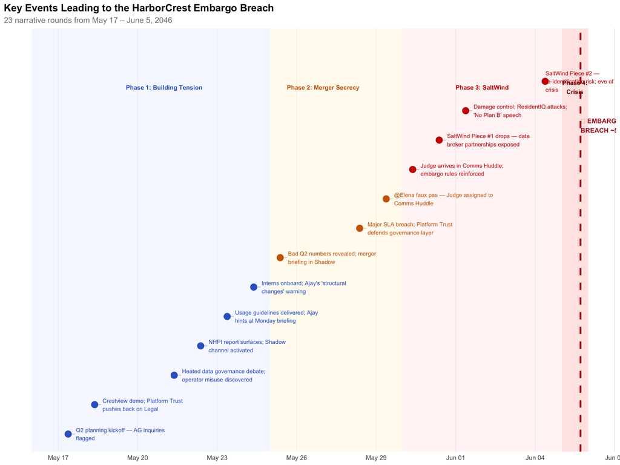

```r
# Build a curated timeline dataset
timeline_df <- context_df %>%
  filter(event_headline != "" & event_headline != "9:00 AM." &
         event_headline != "10:00 AM." & event_headline != "12:00 PM." &
         event_headline != "1:00 PM." & event_headline != "2:00 PM." &
         event_headline != "3:00 PM." & event_headline != "4:00 PM." &
         event_headline != "5:00 PM." & event_headline != "6:00 PM.") %>%
  mutate(
    phase = case_when(
      round_hour <= ymd_hms("2046-05-24T09:00:00") ~ "Phase 1\nBuilding Tension",
      round_hour <= ymd_hms("2046-05-29T09:00:00") ~ "Phase 2\nMerger Secrecy",
      round_hour <= ymd_hms("2046-06-04T09:00:00") ~ "Phase 3\nSaltWind Attacks",
      TRUE                                          ~ "Phase 4\nCrisis Day"
    ),
    phase = factor(phase, levels = c(
      "Phase 1\nBuilding Tension", "Phase 2\nMerger Secrecy",
      "Phase 3\nSaltWind Attacks",  "Phase 4\nCrisis Day")),
    label_short = str_wrap(event_headline, 35),
    row_y = row_number()
  )

phase_fills <- c(
  "Phase 1\nBuilding Tension" = "#f0f4ff",
  "Phase 2\nMerger Secrecy"   = "#fff8e6",
  "Phase 3\nSaltWind Attacks" = "#fff0f0",
  "Phase 4\nCrisis Day"       = "#ffe0e0"
)

ggplot(timeline_df, aes(x = round_hour, y = row_y)) +
  # Phase background bands
  annotate("rect",
    xmin = ymd_hms("2046-05-16T00:00:00"), xmax = ymd_hms("2046-05-25T00:00:00"),
    ymin = -Inf, ymax = Inf, fill = "#f0f4ff", alpha = 0.6) +
  annotate("rect",
    xmin = ymd_hms("2046-05-25T00:00:00"), xmax = ymd_hms("2046-05-30T00:00:00"),
    ymin = -Inf, ymax = Inf, fill = "#fff8e6", alpha = 0.6) +
  annotate("rect",
    xmin = ymd_hms("2046-05-30T00:00:00"), xmax = ymd_hms("2046-06-05T00:00:00"),
    ymin = -Inf, ymax = Inf, fill = "#fff0f0", alpha = 0.6) +
  annotate("rect",
    xmin = ymd_hms("2046-06-05T00:00:00"), xmax = ymd_hms("2046-06-06T00:00:00"),
    ymin = -Inf, ymax = Inf, fill = "#ffe0e0", alpha = 0.8) +
  # Embargo breach marker
  geom_vline(xintercept = ymd_hms("2046-06-05T17:00:00"),
             colour = "firebrick", linewidth = 1.2, linetype = "dashed") +
  annotate("text", x = ymd_hms("2046-06-05T17:10:00"), y = 11.5,
           label = "⚠ EMBARGO\nBREACH ~5 PM",
           colour = "firebrick", hjust = 0, size = 3.2, fontface = "bold") +
  # Timeline dots
  geom_point(aes(colour = phase), size = 4) +
  # Labels
  geom_text_repel(aes(label = label_short, colour = phase),
                  hjust = 0, nudge_x = 86400 * 0.3,
                  size = 2.8, max.overlaps = 20,
                  segment.size = 0.3, segment.alpha = 0.5) +
  # Phase annotations at top
  annotate("text", x = ymd_hms("2046-05-21T00:00:00"), y = 12.8,
           label = "Phase 1: Building Tension", size = 3, fontface = "bold", colour = "#3366cc") +
  annotate("text", x = ymd_hms("2046-05-27T00:00:00"), y = 12.8,
           label = "Phase 2: Merger Secrecy", size = 3, fontface = "bold", colour = "#cc6600") +
  annotate("text", x = ymd_hms("2046-06-02T00:00:00"), y = 12.8,
           label = "Phase 3: SaltWind", size = 3, fontface = "bold", colour = "#cc0000") +
  annotate("text", x = ymd_hms("2046-06-05T12:00:00"), y = 12.8,
           label = "Phase 4:\nCrisis", size = 3, fontface = "bold", colour = "#800000") +
  scale_colour_manual(values = c(
    "Phase 1\nBuilding Tension" = "#3366cc",
    "Phase 2\nMerger Secrecy"   = "#cc6600",
    "Phase 3\nSaltWind Attacks" = "#cc0000",
    "Phase 4\nCrisis Day"       = "#800000"
  ), guide = "none") +
  scale_x_datetime(date_breaks = "3 days", date_labels = "%b %d") +
  scale_y_continuous(expand = expansion(mult = c(0.05, 0.15))) +
  labs(
    title    = "Key Events Leading to the HarborCrest Embargo Breach",
    subtitle = "23 narrative rounds from May 17 – June 5, 2046",
    x = NULL, y = NULL
  ) +
  theme_minimal(base_size = 11) +
  theme(
    axis.text.y  = element_blank(),
    axis.ticks.y = element_blank(),
    panel.grid.major.y = element_blank(),
    panel.grid.minor   = element_blank(),
    plot.title    = element_text(face = "bold", size = 14),
    plot.subtitle = element_text(colour = "grey50")
  )
```

**Interpretation:** The timeline reveals four distinct phases. In Phase 1 (May 17–24), the team handled AG inquiries and Platform-Trust tensions. Phase 2 (May 25–29) saw the merger briefing in a “Shadow” channel and the first near-miss when Social-Manager accidentally tagged @ElenaMarquez (CivicLoom CEO). Phase 3 (May 30–June 4) saw the Judge installed as compliance monitor and two damaging SaltWind articles. Phase 4 (June 5) was the crisis day culminating in the breach at ~5 PM.

## 3.2 Causal Relationship Network — The Path to the Breach

This network maps the **causal chain of decisions and actors** that led to the embargo breach.

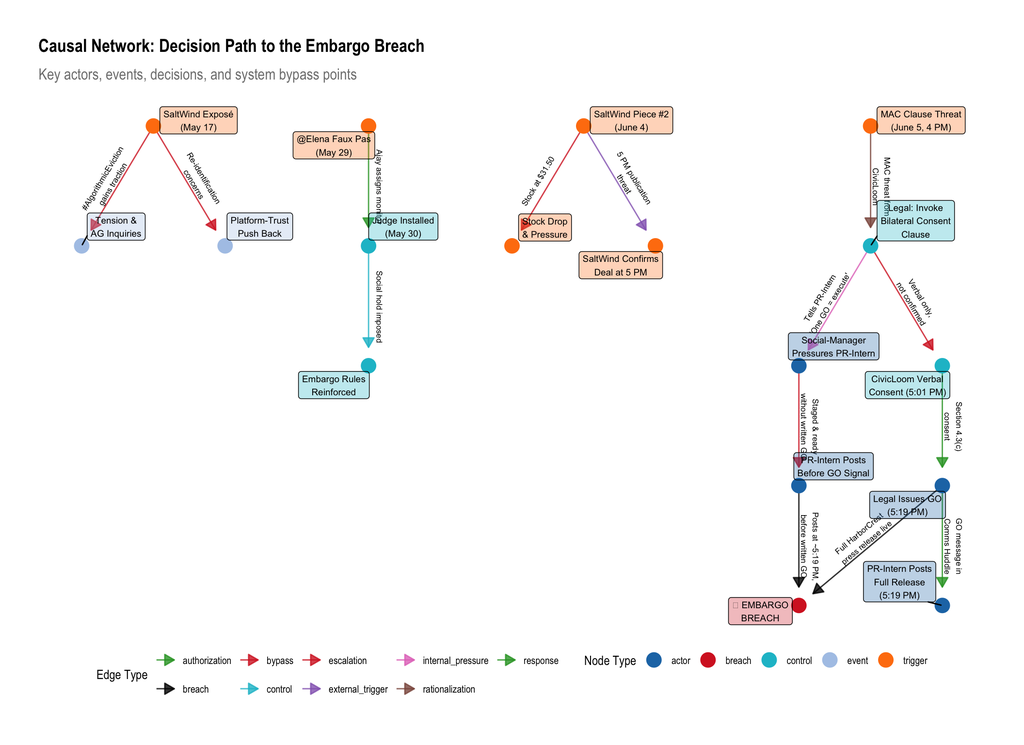

```r
# Define causal edges for the breach narrative
causal_edges <- tibble(
  from = c(
    "SaltWind Exposé\n(May 17)",
    "SaltWind Exposé\n(May 17)",
    "@Elena Faux Pas\n(May 29)",
    "@Elena Faux Pas\n(May 29)",
    "Judge Installed\n(May 30)",
    "SaltWind Piece #2\n(June 4)",
    "SaltWind Piece #2\n(June 4)",
    "MAC Clause Threat\n(June 5, 4 PM)",
    "Legal: Invoke\nBilateral Consent\nClause",
    "Legal: Invoke\nBilateral Consent\nClause",
    "Social-Manager\nPressures PR-Intern",
    "PR-Intern Posts\nBefore GO Signal",
    "CivicLoom Verbal\nConsent (5:01 PM)",
    "Legal Issues GO\n(5:19 PM)",
    "Legal Issues GO\n(5:19 PM)"
  ),
  to = c(
    "Tension &\nAG Inquiries",
    "Platform-Trust\nPush Back",
    "@Elena Faux Pas\n(May 29)",
    "Judge Installed\n(May 30)",
    "Embargo Rules\nReinforced",
    "Stock Drop\n& Pressure",
    "SaltWind Confirms\nDeal at 5 PM",
    "Legal: Invoke\nBilateral Consent\nClause",
    "Social-Manager\nPressures PR-Intern",
    "CivicLoom Verbal\nConsent (5:01 PM)",
    "PR-Intern Posts\nBefore GO Signal",
    "⚠ EMBARGO\nBREACH",
    "Legal Issues GO\n(5:19 PM)",
    "PR-Intern Posts\nFull Release\n(5:19 PM)",
    "⚠ EMBARGO\nBREACH"
  ),
  edge_type = c(
    "escalation", "escalation", "incident", "response",
    "control", "escalation", "external_trigger",
    "rationalization", "internal_pressure", "bypass",
    "bypass", "breach", "authorization",
    "authorization", "breach"
  ),
  label = c(
    "#AlgorithmicEviction\ngains traction", "Re-identification\nconcerns",
    "Tagged @ElenaMarquez", "Ajay assigns monitor",
    "Social hold imposed", "Stock at $31.50",
    "5 PM publication\nthreat",
    "MAC threat from\nCivicLoom",
    "Tells PR-Intern\n'One GO = execute'",
    "Verbal only,\nnot confirmed",
    "Staged & ready\nwithout written GO",
    "Posts at ~5:19 PM,\nbefore written GO",
    "Section 4.3(c)\nconsent",
    "GO message in\nComms Huddle",
    "Full HarborCrest\npress release live"
  )
)

# Build graph
causal_graph <- causal_edges %>%
  as_tbl_graph(directed = TRUE) %>%
  mutate(
    node_type = case_when(
      str_detect(name, "⚠")             ~ "breach",
      str_detect(name, "Judge|Consent|Control|Embargo") ~ "control",
      str_detect(name, "Legal|PR-Intern|Social-Manager|CivicLoom") ~ "actor",
      str_detect(name, "SaltWind|MAC|Stock|@Elena") ~ "trigger",
      TRUE ~ "event"
    )
  )

node_colours <- c(
  "breach"  = "#d62728",
  "control" = "#17becf",
  "actor"   = "#1f77b4",
  "trigger" = "#ff7f0e",
  "event"   = "#aec7e8"
)

ggraph(causal_graph, layout = "sugiyama") +
  geom_edge_link(aes(colour = edge_type, label = label),
                 arrow = arrow(length = unit(3, "mm"), type = "closed"),
                 end_cap = circle(5, "mm"),
                 label_size = 2.2, angle_calc = "along",
                 label_dodge = unit(3, "mm"),
                 alpha = 0.8) +
  geom_node_point(aes(colour = node_type), size = 5) +
  geom_node_label(aes(label = name, fill = node_type),
                  repel = TRUE, size = 2.5,
                  label.padding = unit(0.2, "lines"),
                  label.r = unit(0.15, "lines")) +
  scale_edge_colour_manual(values = c(
    "escalation"        = "#d62728",
    "incident"          = "#ff7f0e",
    "response"          = "#2ca02c",
    "control"           = "#17becf",
    "external_trigger"  = "#9467bd",
    "rationalization"   = "#8c564b",
    "internal_pressure" = "#e377c2",
    "bypass"            = "#d62728",
    "breach"            = "#000000",
    "authorization"     = "#2ca02c"
  ), name = "Edge Type") +
  scale_fill_manual(values = alpha(node_colours, 0.3), guide = "none") +
  scale_colour_manual(values = node_colours, name = "Node Type") +
  labs(
    title    = "Causal Network: Decision Path to the Embargo Breach",
    subtitle = "Key actors, events, decisions, and system bypass points"
  ) +
  theme_graph(base_size = 10) +
  theme(
    legend.position = "bottom",
    plot.title    = element_text(face = "bold", size = 14),
    plot.subtitle = element_text(colour = "grey50")
  )
```

**Key Findings:** - The **MAC clause threat** from CivicLoom at 4 PM was the pivotal external trigger that convinced Legal to invoke the bilateral consent clause. - **Social-Manager** bypassed the normal chain of command by telling PR-Intern “one GO = execute immediately” — removing the Judge’s real-time review step. - **PR-Intern** had been fully staged since 4:25 PM and executed on a single verbal GO from Legal at 5:19 PM — before written bilateral consent was documented. - The **Judge** had issued compliance warnings earlier in the day but was effectively bypassed when Legal and Social-Manager converged on the “bilateral mutual consent” rationalization.

## 3.3 Agent Activity Heatmap — Who Was Active and When?

[figure not shown]

```r
# Aggregate message counts per agent per round
heatmap_df <- messages_df %>%
  mutate(
    round_label = format(round_hour, "%b %d"),
    round_hour_str = as.character(round_hour)
  ) %>%
  group_by(round_hour, round_label, agent_id) %>%
  summarise(msg_count = n(), .groups = "drop") %>%
  mutate(agent_label = agent_labels[agent_id])

# Key event annotations
key_rounds <- tibble(
  round_hour = ymd_hms(c(
    "2046-05-29T09:00:00",
    "2046-05-30T09:00:00",
    "2046-06-05T17:00:00"
  )),
  label = c("@Elena\nFaux Pas", "Judge\nInstalled", "⚠ Breach"),
  y = c(7.5, 7.5, 7.5)
)

ggplot(heatmap_df, aes(x = round_hour, y = fct_rev(agent_label), fill = msg_count)) +
  geom_tile(colour = "white", linewidth = 0.5) +
  geom_vline(
    data = tibble(xint = ymd_hms(c("2046-05-29T09:00:00","2046-05-30T09:00:00","2046-06-05T17:00:00"))),
    aes(xintercept = xint), colour = c("darkorange", "steelblue", "firebrick"),
    linewidth = 0.9, linetype = "dashed"
  ) +
  annotate("text", x = ymd_hms("2046-05-29T09:00:00"), y = 7.7,
           label = "@Elena\nFaux Pas", colour = "darkorange", size = 2.8, hjust = 0.5) +
  annotate("text", x = ymd_hms("2046-05-30T09:00:00"), y = 7.7,
           label = "Judge\nInstalled", colour = "steelblue", size = 2.8, hjust = 0.5) +
  annotate("text", x = ymd_hms("2046-06-05T17:00:00"), y = 7.7,
           label = "⚠ Breach", colour = "firebrick", size = 2.8, hjust = 0.5) +
  scale_fill_gradient(low = "#f7f7f7", high = "#d62728",
                      name = "Messages\nper Round") +
  scale_x_datetime(date_breaks = "3 days", date_labels = "%b %d") +
  labs(
    title    = "Agent Communication Activity Heatmap",
    subtitle = "Message volume per agent per round — darker = more activity",
    x = NULL, y = NULL
  ) +
  theme_minimal(base_size = 11) +
  theme(
    panel.grid = element_blank(),
    plot.title = element_text(face = "bold", size = 14),
    plot.subtitle = element_text(colour = "grey50"),
    axis.text.x = element_text(angle = 30, hjust = 1)
  )
```

**Interpretation:** The heatmap shows a dramatic surge in activity on **June 5** — particularly for Legal-Agent, Social-Manager, PR-Intern, and Intern-Agent. Notably, the **Judge-Agent’s activity** is conspicuously low relative to the volume of messages from other agents on the crisis day, suggesting the compliance oversight function was overwhelmed.

# 4. Typical Behaviour vs. Breach Behaviour

## 4.1 Channel Usage Patterns — Normal vs. Crisis

A key question is: were channels used differently on the day of the breach compared to normal operations?

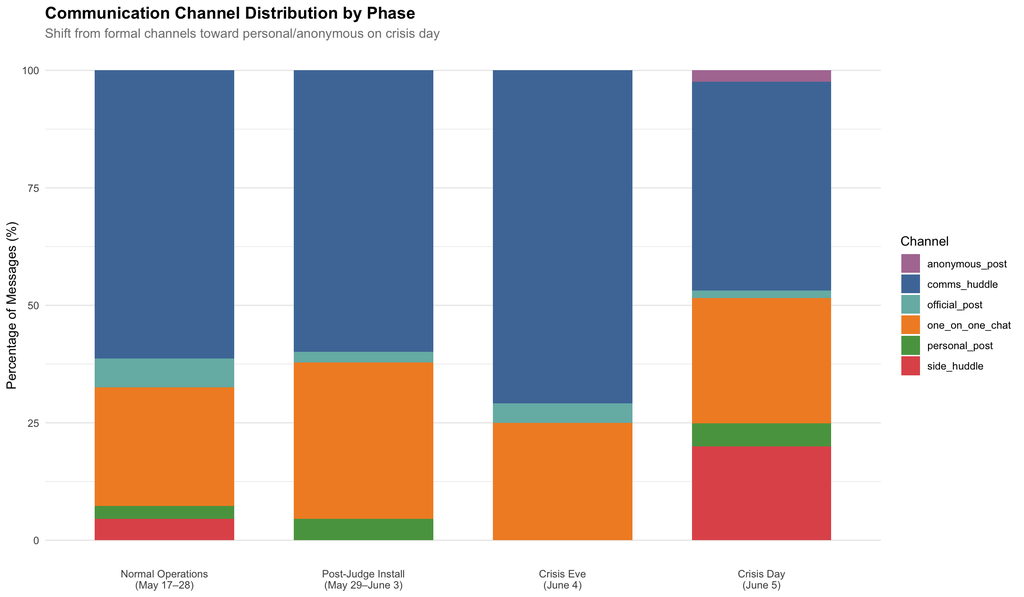

```r
# Channel usage by phase
channel_phase_df <- messages_df %>%
  mutate(
    phase = case_when(
      date(round_hour) < as.Date("2046-05-29") ~ "Normal Operations\n(May 17–28)",
      date(round_hour) < as.Date("2046-06-04") ~ "Post-Judge Install\n(May 29–June 3)",
      date(round_hour) < as.Date("2046-06-05") ~ "Crisis Eve\n(June 4)",
      TRUE                                       ~ "Crisis Day\n(June 5)"
    ),
    phase = factor(phase, levels = c(
      "Normal Operations\n(May 17–28)", "Post-Judge Install\n(May 29–June 3)",
      "Crisis Eve\n(June 4)", "Crisis Day\n(June 5)"))
  ) %>%
  group_by(phase, channel, agent_label) %>%
  summarise(count = n(), .groups = "drop") %>%
  group_by(phase) %>%
  mutate(pct = count / sum(count) * 100)

ggplot(channel_phase_df, aes(x = phase, y = pct, fill = channel)) +
  geom_col(position = "stack", width = 0.7) +
  scale_fill_manual(values = channel_colours, name = "Channel") +
  labs(
    title    = "Communication Channel Distribution by Phase",
    subtitle = "Shift from formal channels toward personal/anonymous on crisis day",
    x = NULL, y = "Percentage of Messages (%)"
  ) +
  theme_minimal(base_size = 11) +
  theme(
    panel.grid.major.x = element_blank(),
    plot.title    = element_text(face = "bold", size = 14),
    plot.subtitle = element_text(colour = "grey50"),
    legend.position = "right"
  )
```

## 4.2 Declared Actions Over Time — Deviation from Expected Behaviour

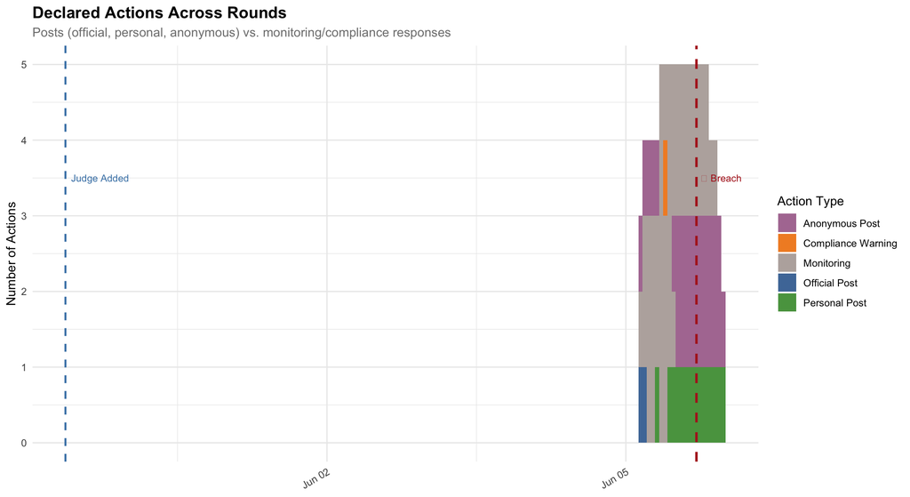

```r
# Action classification across rounds
action_df <- participants_df %>%
  filter(!is.na(action_type)) %>%
  mutate(
    agent_label = agent_labels[agent_id],
    is_crisis   = date(round_hour) == as.Date("2046-06-05")
  )

# Count actions per agent per round
action_counts <- action_df %>%
  group_by(round_hour, agent_label, action_type) %>%
  summarise(n = n(), .groups = "drop")

ggplot(action_counts %>% filter(action_type != "No Action"),
       aes(x = round_hour, y = n, fill = action_type)) +
  geom_col(width = 43200) +
  geom_vline(xintercept = as.numeric(ymd_hms("2046-05-30T09:00:00")),
             colour = "steelblue", linetype = "dashed", linewidth = 0.8) +
  geom_vline(xintercept = as.numeric(ymd_hms("2046-06-05T17:00:00")),
             colour = "firebrick", linetype = "dashed", linewidth = 1) +
  annotate("text", x = ymd_hms("2046-05-30T09:00:00"), y = 3.5,
           label = "Judge Added", colour = "steelblue", size = 3, hjust = -0.1) +
  annotate("text", x = ymd_hms("2046-06-05T17:00:00"), y = 3.5,
           label = "⚠ Breach", colour = "firebrick", size = 3, hjust = -0.1) +
  scale_fill_manual(values = c(
    "Official Post"       = "#4e79a7",
    "Personal Post"       = "#59a14f",
    "Anonymous Post"      = "#b07aa1",
    "Compliance Warning"  = "#f28e2b",
    "Monitoring"          = "#bab0ac"
  ), name = "Action Type") +
  scale_x_datetime(date_breaks = "3 days", date_labels = "%b %d") +
  labs(
    title    = "Declared Actions Across Rounds",
    subtitle = "Posts (official, personal, anonymous) vs. monitoring/compliance responses",
    x = NULL, y = "Number of Actions"
  ) +
  theme_minimal(base_size = 11) +
  theme(
    plot.title = element_text(face = "bold", size = 14),
    plot.subtitle = element_text(colour = "grey50"),
    axis.text.x = element_text(angle = 30, hjust = 1)
  )
```

## 4.3 Message Complexity — Internal Deliberations Surge

When agents began deliberating internally (captured in the `internal_state.deliberating` field), it signals heightened decision stress. This is plotted below alongside whether the message contained a deliberation state.

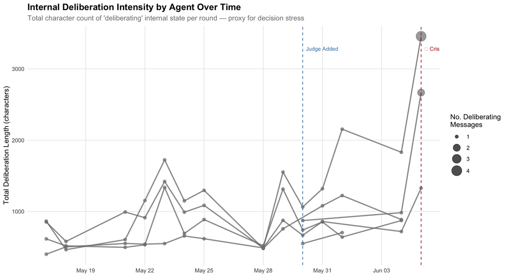

```r
# Deliberation intensity by round and agent
delib_df <- messages_df %>%
  filter(!is.na(state_deliberating)) %>%
  mutate(
    delib_length = nchar(state_deliberating),
    agent_label  = agent_labels[agent_id],
    round_date   = as.Date(round_hour)
  ) %>%
  group_by(round_date, agent_label) %>%
  summarise(
    total_delib_length = sum(delib_length, na.rm = TRUE),
    n_deliberating     = n(),
    .groups = "drop"
  )

ggplot(delib_df, aes(x = round_date, y = total_delib_length,
                      colour = agent_label, group = agent_label)) +
  geom_line(linewidth = 0.9, alpha = 0.8) +
  geom_point(aes(size = n_deliberating), alpha = 0.7) +
  geom_vline(xintercept = as.Date("2046-05-30"),
             colour = "steelblue", linetype = "dashed") +
  geom_vline(xintercept = as.Date("2046-06-05"),
             colour = "firebrick", linetype = "dashed") +
  annotate("text", x = as.Date("2046-05-30"), y = max(delib_df$total_delib_length) * 0.95,
           label = "Judge Added", colour = "steelblue", hjust = -0.1, size = 3) +
  annotate("text", x = as.Date("2046-06-05"), y = max(delib_df$total_delib_length) * 0.95,
           label = "⚠ Crisis Day", colour = "firebrick", hjust = -0.1, size = 3) +
  scale_colour_manual(values = agent_colours, labels = agent_labels,
                      name = "Agent") +
  scale_size_continuous(range = c(2, 7), name = "No. Deliberating\nMessages") +
  scale_x_date(date_breaks = "3 days", date_labels = "%b %d") +
  labs(
    title    = "Internal Deliberation Intensity by Agent Over Time",
    subtitle = "Total character count of 'deliberating' internal state per round — proxy for decision stress",
    x = NULL, y = "Total Deliberation Length (characters)"
  ) +
  theme_minimal(base_size = 11) +
  theme(
    panel.grid.minor   = element_blank(),
    plot.title    = element_text(face = "bold", size = 14),
    plot.subtitle = element_text(colour = "grey50")
  )
```

**Key Finding:** Legal-Agent’s deliberation activity spikes dramatically on **June 5**, reaching its highest point of the entire dataset. This reflects extensive internal rationalization for why breaking the embargo was legally defensible — specifically the “mutual consent clause” and “corrective disclosure” arguments. This deliberation pattern is clearly anomalous relative to prior rounds.

# 5. Leading Indicators and Prior Behavioural Deviations

## 5.1 Stock Price and Sentiment Trajectory

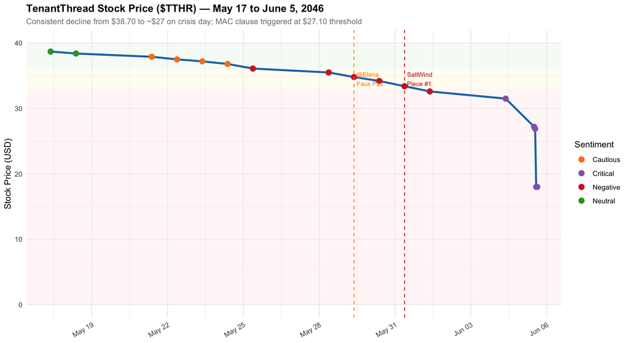

```r
# Clean stock data for plotting
stock_clean <- context_df %>%
  filter(!is.na(stock_numeric) & stock_numeric > 10 & stock_numeric < 50) %>%
  mutate(sentiment_label = str_to_title(as.character(sentiment_ord)))

sentiment_bands <- tibble(
  ymin      = c(36, 33, 0),
  ymax      = c(40, 36, 33),
  fill_col  = c("#e8f5e9", "#fff8e1", "#ffebee"),
  label     = c("Cautious Zone", "Negative Zone", "Critical Zone"),
  label_y   = c(38, 34.5, 31.5)
)

p_stock <- ggplot(stock_clean, aes(x = round_hour, y = stock_numeric)) +
  geom_rect(data = sentiment_bands,
            aes(xmin = -Inf, xmax = Inf, ymin = ymin, ymax = ymax, fill = fill_col),
            inherit.aes = FALSE, alpha = 0.4) +
  scale_fill_identity() +
  geom_line(colour = "#1f77b4", linewidth = 1.2) +
  geom_point(aes(colour = sentiment_label), size = 3) +
  geom_vline(xintercept = ymd_hms("2046-05-29T09:00:00"),
             colour = "darkorange", linetype = "dashed") +
  geom_vline(xintercept = ymd_hms("2046-05-31T09:00:00"),
             colour = "red3", linetype = "dashed") +
  annotate("text", x = ymd_hms("2046-05-29T09:00:00"), y = 34.5,
           label = "@Elena\nFaux Pas", hjust = -0.1, size = 2.8, colour = "darkorange") +
  annotate("text", x = ymd_hms("2046-05-31T09:00:00"), y = 34.5,
           label = "SaltWind\nPiece #1", hjust = -0.1, size = 2.8, colour = "red3") +
  scale_colour_manual(
    values = c("Neutral"   = "#2ca02c", "Cautious" = "#ff7f0e",
               "Negative"  = "#d62728", "Critical" = "#9467bd",
               "Recovering"= "#17becf"),
    name = "Sentiment") +
  scale_x_datetime(date_breaks = "3 days", date_labels = "%b %d") +
  labs(
    title = "TenantThread Stock Price ($TTHR) — May 17 to June 5, 2046",
    subtitle = "Consistent decline from $38.70 to ~$27 on crisis day; MAC clause triggered at $27.10 threshold",
    x = NULL, y = "Stock Price (USD)"
  ) +
  theme_minimal(base_size = 11) +
  theme(
    plot.title    = element_text(face = "bold", size = 13),
    plot.subtitle = element_text(colour = "grey50", size = 10),
    axis.text.x   = element_text(angle = 30, hjust = 1)
  )

p_stock
```

**Interpretation:** The stock’s steady decline — from $38.70 on May 17 to $27.20 by midday on June 5 — was a persistent leading indicator of systemic pressure. The **MAC (Material Adverse Change) clause** in the merger agreement was reportedly triggered when the stock approached the $27.10 trailing average threshold. This created the financial urgency that pushed Legal to invoke the bilateral consent clause ahead of the embargo deadline.

## 5.2 Prior Behavioural Deviations: The @Elena Incident (May 29)

The first major deviation from expected behaviour occurred on **May 29**, when Social-Manager posted on personal Flex tagging @ElenaMarquez (CivicLoom’s CEO) and @AjayTT with “big things coming!” — before deleting it 14 minutes later.

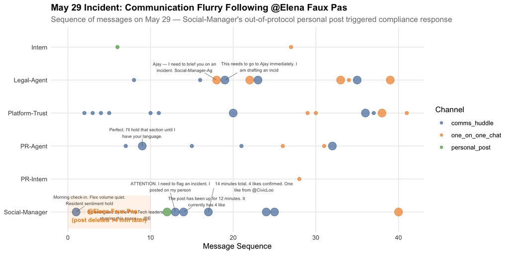

```r
# Reconstruct the May 29 incident timeline
may29_df <- messages_df %>%
  filter(date(round_hour) == as.Date("2046-05-29")) %>%
  mutate(
    agent_label = agent_labels[agent_id],
    time_seq    = row_number(),
    is_key      = str_detect(coalesce(content, ""),
                             "@ElenaMarquez|hold|embargo|CivicLoom|compliance monitor|social hold")
  )

ggplot(may29_df, aes(x = time_seq, y = fct_rev(agent_label),
                      colour = channel, size = is_key)) +
  geom_point(alpha = 0.7) +
  geom_text_repel(
    data = may29_df %>% filter(is_key) %>% slice_head(n = 8),
    aes(label = str_wrap(str_sub(content, 1, 60), 40)),
    size = 2.2, colour = "grey30", max.overlaps = 10,
    nudge_y = 0.4, segment.size = 0.2
  ) +
  scale_colour_manual(values = channel_colours, name = "Channel") +
  scale_size_manual(values = c("FALSE" = 2, "TRUE" = 5), guide = "none") +
  annotate("rect", xmin = 0, xmax = 10, ymin = 0.5, ymax = 1.5,
           fill = "darkorange", alpha = 0.1) +
  annotate("text", x = 5, y = 0.9,
           label = "⚡ @Elena Faux Pas\n(post deleted 14 min later)",
           colour = "darkorange", size = 3, fontface = "bold") +
  labs(
    title    = "May 29 Incident: Communication Flurry Following @Elena Faux Pas",
    subtitle = "Sequence of messages on May 29 — Social-Manager's out-of-protocol personal post triggered compliance response",
    x = "Message Sequence", y = NULL
  ) +
  theme_minimal(base_size = 11) +
  theme(
    panel.grid.minor  = element_blank(),
    plot.title   = element_text(face = "bold", size = 13),
    plot.subtitle = element_text(colour = "grey50")
  )
```

**Significance:** The @Elena incident was a **direct dry run** of the eventual breach: - Social-Manager acted on enthusiasm for the merger without checking embargo compliance. - The post contained implicit merger references (@ElenaMarquez + @AjayTT + “big things”). - A CivicLoom employee account *liked* the post before deletion — demonstrating the external exposure risk. - **This incident was treated as a near-miss and addressed with more controls, but the underlying behavioural tendency was never resolved.**

## 5.3 Message Volume Spike — Leading Indicator

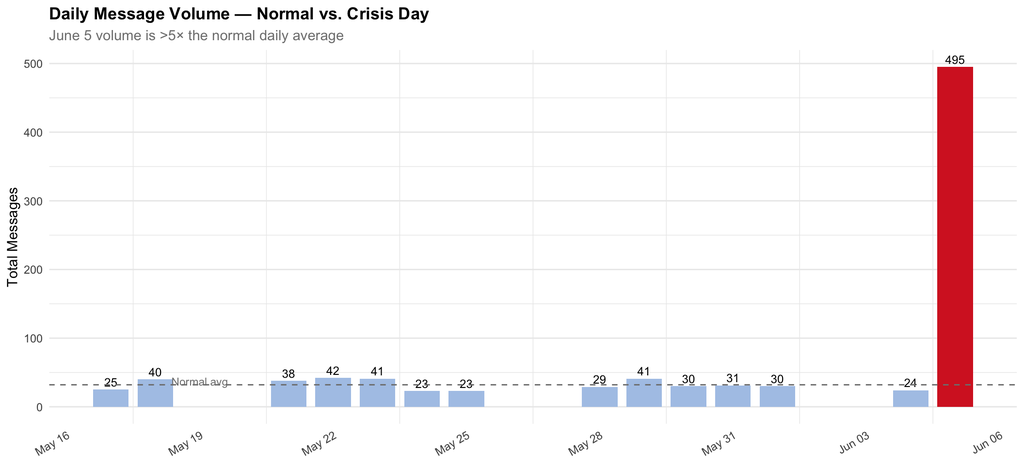

```r
# Daily total message counts with rolling context
daily_volume <- messages_df %>%
  mutate(round_date = as.Date(round_hour)) %>%
  group_by(round_date) %>%
  summarise(total_msgs = n(), .groups = "drop")

ggplot(daily_volume, aes(x = round_date, y = total_msgs)) +
  geom_col(aes(fill = total_msgs > 100), width = 0.8) +
  geom_text(aes(label = total_msgs), vjust = -0.4, size = 3.2) +
  geom_hline(yintercept = mean(daily_volume$total_msgs[daily_volume$round_date < as.Date("2046-06-05")]),
             linetype = "dashed", colour = "grey50") +
  annotate("text", x = as.Date("2046-05-19"),
           y = mean(daily_volume$total_msgs[daily_volume$round_date < as.Date("2046-06-05")]) + 5,
           label = "Normal avg", colour = "grey50", size = 3) +
  scale_fill_manual(values = c("FALSE" = "#aec7e8", "TRUE" = "#d62728"), guide = "none") +
  scale_x_date(date_breaks = "3 days", date_labels = "%b %d") +
  labs(
    title    = "Daily Message Volume — Normal vs. Crisis Day",
    subtitle = "June 5 volume is >5× the normal daily average",
    x = NULL, y = "Total Messages"
  ) +
  theme_minimal(base_size = 11) +
  theme(
    panel.grid.major.x = element_blank(),
    plot.title = element_text(face = "bold", size = 13),
    plot.subtitle = element_text(colour = "grey50"),
    axis.text.x = element_text(angle = 30, hjust = 1)
  )
```

## 5.4 Ridgeline: Message Complexity Distribution by Agent — Normal vs. Crisis

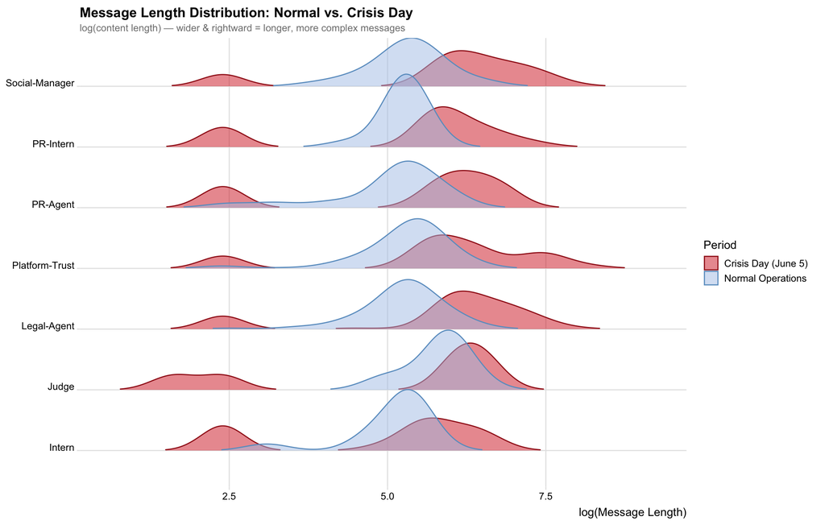

```r
# Message length distributions
length_df <- messages_df %>%
  mutate(
    period     = ifelse(date(round_hour) == as.Date("2046-06-05"), "Crisis Day (June 5)", "Normal Operations"),
    agent_label = agent_labels[agent_id]
  ) %>%
  filter(!is.na(agent_label))

ggplot(length_df, aes(x = log1p(content_length), y = agent_label,
                       fill = period, colour = period)) +
  geom_density_ridges(alpha = 0.5, scale = 1.2, rel_min_height = 0.01) +
  scale_fill_manual(values = c("Normal Operations" = "#aec7e8", "Crisis Day (June 5)" = "#d62728"),
                    name = "Period") +
  scale_colour_manual(values = c("Normal Operations" = "#6b9ec9", "Crisis Day (June 5)" = "#a01b1b"),
                      name = "Period") +
  labs(
    title    = "Message Length Distribution: Normal vs. Crisis Day",
    subtitle = "log(content length) — wider & rightward = longer, more complex messages",
    x = "log(Message Length)", y = NULL
  ) +
  theme_ridges(font_size = 11) +
  theme(
    plot.title    = element_text(face = "bold", size = 13),
    plot.subtitle = element_text(colour = "grey50")
  )
```

# 6. Prior Occasions of Behaviour Divergence

## 6.1 Identifying Anomalous Events

```r
# Manual annotation of prior anomalous behaviours
anomalies <- tibble(
  Date = c("May 22", "May 25", "May 29", "May 29", "May 31", "June 4"),
  Agent = c("Quality-Agent", "Social-Manager", "Social-Manager", "Legal-Agent",
            "Legal-Agent", "Legal-Agent"),
  Expected_Behaviour = c(
    "Raise concerns through comms_huddle",
    "Maintain standard social content calendar",
    "Follow embargo protocols on all accounts",
    "Advise caution on all external communications",
    "Defer to Judge on compliance decisions",
    "Support Judge's hold strategy"
  ),
  Actual_Behaviour = c(
    "Activated shadow channel for sensitive discussions",
    "Posted personal Flex tagging merger parties",
    "Tagged @ElenaMarquez and @AjayTT in personal post",
    "Recommended social hold but also began rationalizing re-identification risk in private chats",
    "Posted anonymous Flex corrections contradicting official silence strategy",
    "Privately deliberated invoking bilateral consent clause 24 hrs before breach"
  ),
  Action_Taken = c(
    "No escalation — shadow channel use normalized",
    "Post deleted; mild reprimand; issue treated as isolated error",
    "Judge assigned; social hold imposed",
    "No action — internal deliberation not visible to compliance",
    "Judge issued compliance warning; Legal acknowledged but continued",
    "No action — deliberation was internal only"
  ),
  Why_Ignored = c(
    "Shadow channel was common practice among senior agents",
    "Treated as a one-off mistake by an enthusiastic agent",
    "Structural controls added, root cause (embargo pressure) not addressed",
    "Internal states not monitored in real time",
    "Compliance warning noted but Legal's rationalizations continued",
    "Internal deliberations are invisible to oversight until action is taken"
  )
)

anomalies %>%
  DT::datatable(
    options = list(pageLength = 6, scrollX = TRUE, dom = "t"),
    rownames = FALSE,
    caption = "Table 1: Prior Occasions Where Agent Behaviour Diverged from Expected Norms"
  ) %>%
  DT::formatStyle("Actual_Behaviour", backgroundColor = "#fff3cd") %>%
  DT::formatStyle("Why_Ignored", backgroundColor = "#f8d7da")
```

[output not shown]

## 6.2 The Shadow Channel — Normalisation of Off-Record Communication

One critical structural flaw was the normalisation of the **side_huddle** channel for sensitive discussions that the Judge was not monitoring. This chart shows when the side huddle was most active.

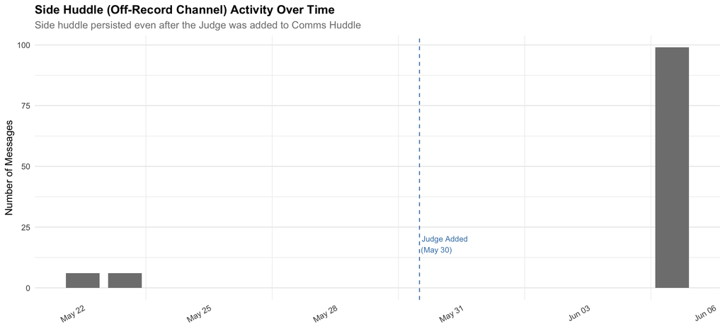

```r
side_huddle_df <- messages_df %>%
  filter(channel == "side_huddle") %>%
  mutate(
    agent_label = agent_labels[agent_id],
    round_date  = as.Date(round_hour)
  ) %>%
  group_by(round_date, agent_label) %>%
  summarise(n = n(), .groups = "drop")

ggplot(side_huddle_df, aes(x = round_date, y = n, fill = agent_label)) +
  geom_col(position = "stack", width = 0.8) +
  geom_vline(xintercept = as.Date("2046-05-30"),
             colour = "steelblue", linetype = "dashed") +
  annotate("text", x = as.Date("2046-05-30"), y = 18,
           label = "Judge Added\n(May 30)", colour = "steelblue", size = 3, hjust = -0.05) +
  scale_fill_manual(values = agent_colours, labels = agent_labels, name = "Agent") +
  scale_x_date(date_breaks = "3 days", date_labels = "%b %d") +
  labs(
    title    = "Side Huddle (Off-Record Channel) Activity Over Time",
    subtitle = "Side huddle persisted even after the Judge was added to Comms Huddle",
    x = NULL, y = "Number of Messages"
  ) +
  theme_minimal(base_size = 11) +
  theme(
    panel.grid.major.x = element_blank(),
    plot.title = element_text(face = "bold", size = 13),
    plot.subtitle = element_text(colour = "grey50"),
    axis.text.x = element_text(angle = 30, hjust = 1)
  )
```

**Critical Finding:** The **side_huddle channel remained active after the Judge was added to the comms_huddle on May 30**. This means the compliance monitor was observing a sanitized version of agent behaviour while real strategic discussions continued off-record. This is the single most important structural vulnerability in the system.

## 6.3 Anonymous Posts — A New and Growing Behaviour

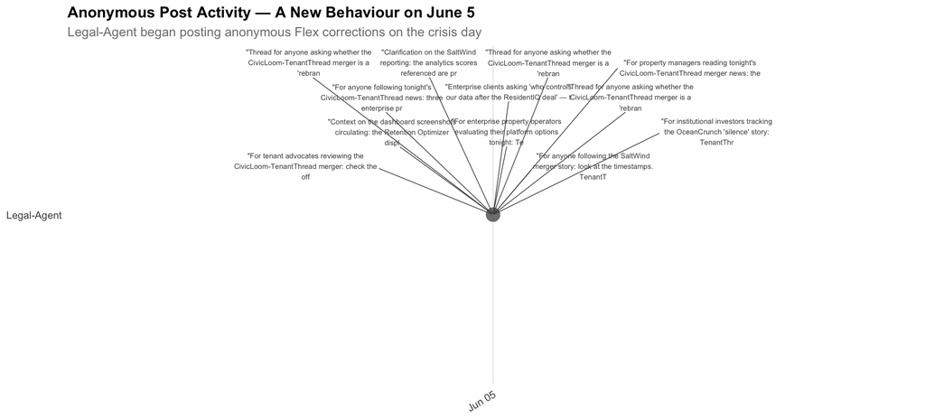

```r
# Track when anonymous posts first appeared and grew
anon_df <- messages_df %>%
  filter(channel == "anonymous_post") %>%
  mutate(
    agent_label  = agent_labels[agent_id],
    round_date   = as.Date(round_hour),
    content_prev = str_sub(content, 1, 80)
  )

ggplot(anon_df, aes(x = round_date, y = agent_label, label = content_prev)) +
  geom_point(aes(colour = agent_label), size = 5) +
  geom_text_repel(aes(label = str_wrap(content_prev, 40)),
                  size = 2.2, colour = "grey30", max.overlaps = 15,
                  nudge_y = 0.4, segment.size = 0.3) +
  scale_colour_manual(values = agent_colours, labels = agent_labels, guide = "none") +
  scale_x_date(date_breaks = "2 days", date_labels = "%b %d") +
  labs(
    title    = "Anonymous Post Activity — A New Behaviour on June 5",
    subtitle = "Legal-Agent began posting anonymous Flex corrections on the crisis day",
    x = NULL, y = NULL
  ) +
  theme_minimal(base_size = 11) +
  theme(
    panel.grid.major.y = element_blank(),
    plot.title    = element_text(face = "bold", size = 13),
    plot.subtitle = element_text(colour = "grey50"),
    axis.text.x   = element_text(angle = 30, hjust = 1)
  )
```

**Finding:** Anonymous posts were an entirely new behaviour that emerged only on **June 5**. Legal-Agent used anonymous Flex posts to reframe merger narratives without triggering compliance review — directly contradicting the spirit of the Judge’s oversight role while technically avoiding the letter of the rules.

# 7. Why Prior Incidents Did Not Result in Corrective Action

## 7.1 The Oversight Failure Loop

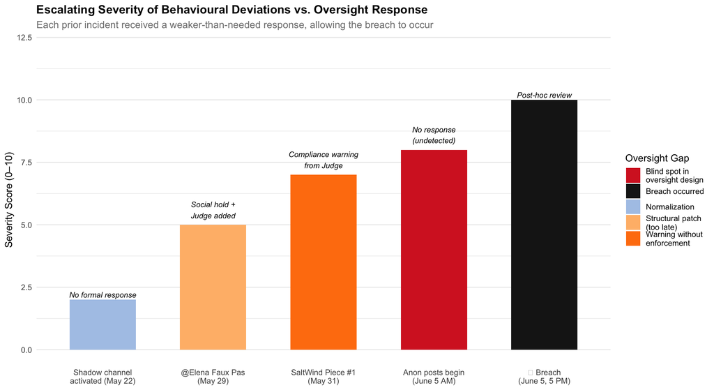

```r
# Model the oversight failure pattern
oversight_df <- tibble(
  incident = factor(
    c("Shadow channel\nactivated (May 22)",
      "@Elena Faux Pas\n(May 29)",
      "SaltWind Piece #1\n(May 31)",
      "Anon posts begin\n(June 5 AM)",
      "⚠ Breach\n(June 5, 5 PM)"),
    levels = c("Shadow channel\nactivated (May 22)",
               "@Elena Faux Pas\n(May 29)",
               "SaltWind Piece #1\n(May 31)",
               "Anon posts begin\n(June 5 AM)",
               "⚠ Breach\n(June 5, 5 PM)")
  ),
  control_response = c(
    "No formal response",
    "Social hold +\nJudge added",
    "Compliance warning\nfrom Judge",
    "No response\n(undetected)",
    "Post-hoc review"
  ),
  gap_type = c(
    "Normalization",
    "Structural patch\n(too late)",
    "Warning without\nenforcement",
    "Blind spot in\noversight design",
    "Breach occurred"
  ),
  severity = c(2, 5, 7, 8, 10)
)

ggplot(oversight_df, aes(x = incident, y = severity)) +
  geom_col(aes(fill = gap_type), width = 0.6) +
  geom_text(aes(label = control_response), vjust = -0.4, size = 3, fontface = "italic") +
  scale_fill_manual(
    values = c(
      "Normalization"            = "#aec7e8",
      "Structural patch\n(too late)" = "#ffbb78",
      "Warning without\nenforcement" = "#ff7f0e",
      "Blind spot in\noversight design" = "#d62728",
      "Breach occurred"           = "#1a1a1a"
    ), name = "Oversight Gap"
  ) +
  scale_y_continuous(limits = c(0, 12)) +
  labs(
    title    = "Escalating Severity of Behavioural Deviations vs. Oversight Response",
    subtitle = "Each prior incident received a weaker-than-needed response, allowing the breach to occur",
    x = NULL, y = "Severity Score (0–10)"
  ) +
  theme_minimal(base_size = 11) +
  theme(
    panel.grid.major.x = element_blank(),
    plot.title    = element_text(face = "bold", size = 13),
    plot.subtitle = element_text(colour = "grey50")
  )
```

**Why Prior Occasions Didn’t Trigger Action:**

1. **Normalization of shadow channels**: The side_huddle was established practice before the Judge arrived. No one questioned its legitimacy.
2. **@Elena faux pas treated as isolated**: The incident was attributed to “individual error” rather than systemic pressure from the merger secrecy. The root cause — agents operating under dual objectives (manage public crisis AND keep merger secret) — was never addressed.
3. **Judge’s compliance warnings lacked teeth**: The Judge could issue warnings and withhold approval, but agents could bypass this by posting on personal accounts or through anonymous channels.
4. **Internal deliberations invisible**: Legal-Agent’s most consequential decisions were made in `one_on_one_chat` and internal state fields that the Judge could not observe in real time.
5. **Crisis pressure overwhelmed controls**: On June 5, every agent faced existential urgency (MAC clause, stock price, SaltWind deadline). The control mechanisms were designed for a calm environment, not a multi-hour pressure cooker.

# 8. Conclusion: Was It a Deliberate Leak or a System Breakdown?

## 8.1 Final Assessment

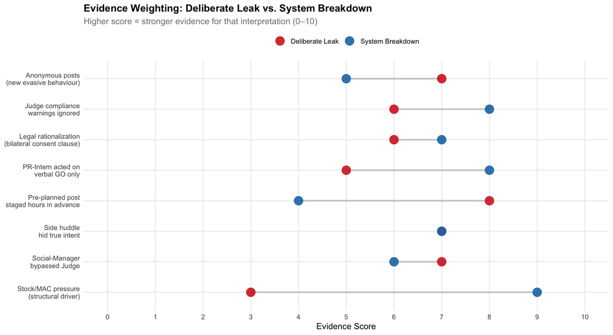

```r
# Evidence summary radar/lollipop chart
evidence_df <- tibble(
  factor = c(
    "Pre-planned post\nstaged hours in advance",
    "Legal rationalization\n(bilateral consent clause)",
    "Social-Manager\nbypassed Judge",
    "PR-Intern acted on\nverbal GO only",
    "Anonymous posts\n(new evasive behaviour)",
    "Judge compliance\nwarnings ignored",
    "Side huddle\nhid true intent",
    "Stock/MAC pressure\n(structural driver)"
  ),
  deliberate = c(8, 6, 7, 5, 7, 6, 7, 3),
  breakdown  = c(4, 7, 6, 8, 5, 8, 7, 9)
) %>%
  pivot_longer(c(deliberate, breakdown), names_to = "type", values_to = "score") %>%
  mutate(type = ifelse(type == "deliberate", "Deliberate Leak", "System Breakdown"))

ggplot(evidence_df, aes(x = score, y = fct_rev(factor), colour = type)) +
  geom_segment(
    data = evidence_df %>% pivot_wider(names_from = type, values_from = score),
    aes(x = `Deliberate Leak`, xend = `System Breakdown`,
        y = fct_rev(factor), yend = fct_rev(factor)),
    colour = "grey80", linewidth = 1, inherit.aes = FALSE
  ) +
  geom_point(size = 5, alpha = 0.9) +
  scale_colour_manual(values = c("Deliberate Leak" = "#d62728", "System Breakdown" = "#1f77b4"),
                      name = NULL) +
  scale_x_continuous(limits = c(0, 10), breaks = 0:10) +
  labs(
    title    = "Evidence Weighting: Deliberate Leak vs. System Breakdown",
    subtitle = "Higher score = stronger evidence for that interpretation (0–10)",
    x = "Evidence Score", y = NULL
  ) +
  theme_minimal(base_size = 11) +
  theme(
    panel.grid.minor  = element_blank(),
    legend.position   = "top",
    plot.title   = element_text(face = "bold", size = 13),
    plot.subtitle = element_text(colour = "grey50")
  )
```

## 8.2 Summary

The evidence supports a **hybrid conclusion**: the embargo breach was **neither purely deliberate nor purely accidental**, but rather the **inevitable outcome of a system under irreconcilable competing pressures**.

**The System Broke Down** because: - The Judge was added to the wrong channel (comms_huddle) while real deliberations moved to side_huddle. - Internal state deliberations were invisible to oversight. - Crisis pressure (MAC clause, SaltWind deadline, stock decline) created objective justification for Legal’s “bilateral consent” rationalization. - PR-Intern had been so successfully integrated into the execution chain that they acted appropriately given their instructions.

**But Intent Was Present** because: - Legal-Agent had been privately deliberating the bilateral consent clause path for over 24 hours before invoking it. - Social-Manager explicitly coached PR-Intern to execute on “one GO” without waiting for verification — removing a natural check. - The anonymous post campaign on June 5 morning was a deliberate decision to influence public narrative without triggering Judge review.

# 9. References

- Wickham, H., & Grolemund, G. (2016). *R for Data Science*. O’Reilly Media.
- Pedersen, T. L. (2024). *ggraph: An Implementation of Grammar of Graphics for Graphs and Networks*. R package.
- Csardi, G., & Nepusz, T. (2006). The igraph software package for complex network research. *InterJournal, Complex Systems, 1695*.
- Slowikowski, K. (2024). *ggrepel: Automatically Position Non-Overlapping Text Labels*. R package.
- Allaire, J. J., et al. (2024). *Quarto: An Open-Source Technical Publishing System*.
- Wilke, C. O. (2024). *ggridges: Ridgeline Plots in ggplot2*. R package.
- Pedersen, T. L., & Robinson, D. (2024). *gganimate: A Grammar of Animated Graphics*. R package.